# 8 对应分析习题答案

Li Zongzhang

2022-11-15

# 习题2

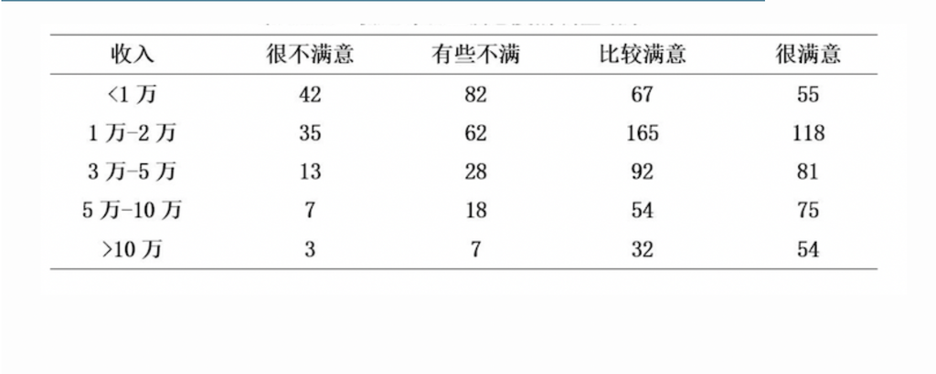

提示：数据请自行录入，可在EXCEL录入好后，再导入R。

要求： 2.1 对行变量和列变量进行独立性检验，独立性检验的卡方检验统计量是多少？P值是什么，你的检验结论是什么？

2.2 绘制碎石图。你提取几个维度？每个维度的贡献分别是多少？

2.3 绘制对应分析图。

2.4 绘制行变量的contribution、cos2的图像。

2.5 绘制列变量的contribution、cos2的图像。

2.6 从图中可以发现哪些组别关系紧密？

## 创建列联表的数据框

```r
#创建列联表的数据框
ex2 <- data.frame(
  very_dissatisfied = c(42,35,13,7,3),
  somewhat_dissatified = c(82,62,28,18,7),
  somewhat_satisfied = c(67,165,92,54,32),
  very_satisfied = c(55, 118,81,75,54)
)

#给ex2添加行名，以便在图中能添加标签
rownames(ex2) <- c("less than 10k", "10k-30k",
                   "30k-50k", "50k-100k", "more than 100k")
ex2
```

```
               very_dissatisfied somewhat_dissatified somewhat_satisfied
less than 10k                 42                   82                 67
10k-30k                       35                   62                165
30k-50k                       13                   28                 92
50k-100k                       7                   18                 54
more than 100k                 3                    7                 32
               very_satisfied
less than 10k              55
10k-30k                   118
30k-50k                    81
50k-100k                   75
more than 100k             54
```

## 2.1 独立性检验

```r
#2.1 对行变量和列变量进行独立性检验，独立性检验的卡方检验统计量是多少？P值是什么，你的检验结论是什么？

chisq.test(ex2)
```

```
    Pearson's Chi-squared test

data:  ex2
X-squared = 118.1, df = 12, p-value < 2.2e-16
```

```r
#卡方检验统计量是118.1, P值接近于0。在0.01的显著性水平下，拒绝“收入等级和满意度等级相互独立”的原假设。
```

## 2.2 绘制碎石图

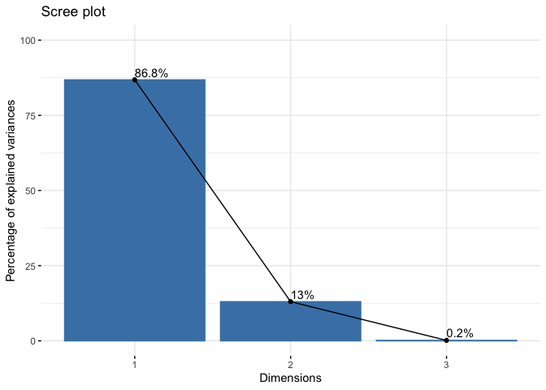

```r
#2.2 绘制碎石图。你提取几个维度？每个维度的贡献分别是多少？

library(FactoMineR)
res.ca <- CA(ex2, graph = FALSE)

#绘制scree plot
library(factoextra)
fviz_screeplot(res.ca, addlabels = TRUE, ylim = c(0, 100))
```

```r
#提取两个维度，维度1的贡献是86.8%， 维度2的贡献是13.0%.
```

## 2.3 绘制对应分析图

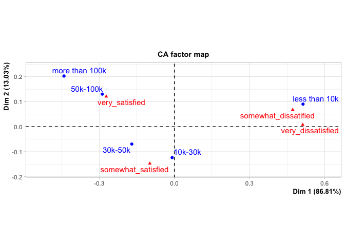

```
**Results of the Correspondence Analysis (CA)**
The row variable has  5  categories; the column variable has 4 categories
The chi square of independence between the two variables is equal to 118.0959 (p-value =  1.48029e-19 ).
*The results are available in the following objects:

   name              description
1  "$eig"            "eigenvalues"
2  "$col"            "results for the columns"
3  "$col$coord"      "coord. for the columns"
4  "$col$cos2"       "cos2 for the columns"
5  "$col$contrib"    "contributions of the columns"
6  "$row"            "results for the rows"
7  "$row$coord"      "coord. for the rows"
8  "$row$cos2"       "cos2 for the rows"
9  "$row$contrib"    "contributions of the rows"
10 "$call"           "summary called parameters"
11 "$call$marge.col" "weights of the columns"
12 "$call$marge.row" "weights of the rows"
```

```r
#2.3 绘制对应分析图
CA(ex2)
```

## 2.4 绘制行变量的contribution/cos2图像

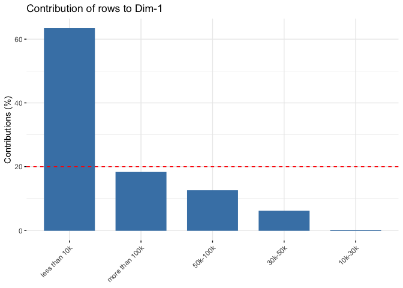

```r
#2.4 绘制行变量的contribution的图像。

#行变量对维度1的贡献
fviz_contrib(res.ca, choice = "row", axes = 1)
```

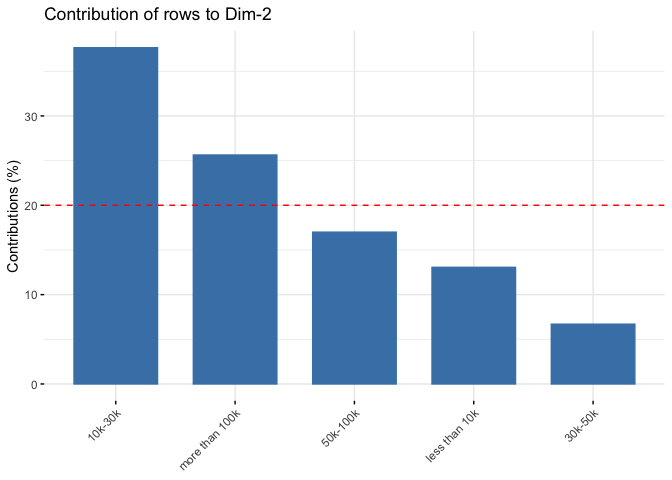

```r
#行变量对维度2的贡献
fviz_contrib(res.ca, choice = "row", axes = 2)
```

```r
#2.4 绘制行变量的cos2的图像。
row <- get_ca_row(res.ca)
row$cos2
```

```
                     Dim 1      Dim 2        Dim 3
less than 10k  0.969960339 0.03003387 5.791844e-06
10k-30k        0.005022974 0.98842064 6.556387e-03
30k-50k        0.848488225 0.14144329 1.006848e-02
50k-100k       0.828708215 0.16984574 1.446041e-03
more than 100k 0.823408163 0.17415844 2.433397e-03
```

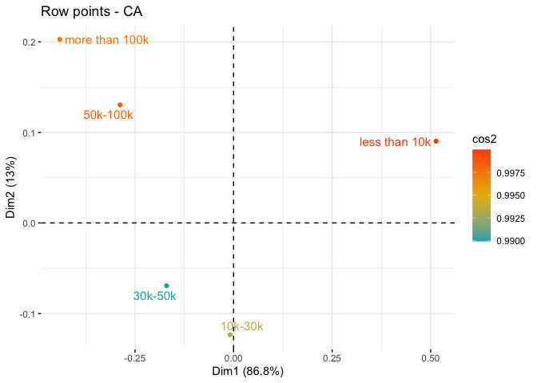

```r
#维度对行变量的代表性cos2（representation）
fviz_ca_row(res.ca, col.row = "cos2",
             gradient.cols = c("#00AFBB", "#E7B800", "#FC4E07"),
             repel = TRUE)
```

## 2.5 绘制列变量的contribution/cos2图像

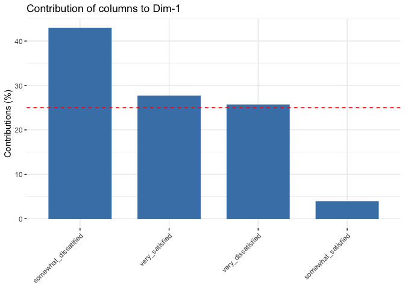

```r
#2.5 绘制列变量的contribution的图像。

#列变量对维度1的贡献
fviz_contrib(res.ca, choice = "col", axes = 1)
```

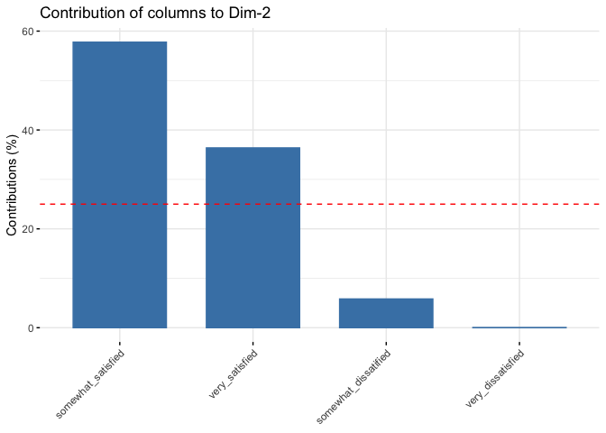

```r
#列变量对维度2的贡献
fviz_contrib(res.ca, choice = "col", axes = 2)
```

```r
#2.5 绘制列变量的cos2的图像。
col <- get_ca_col(res.ca)
col$cos2
```

```
                         Dim 1        Dim 2        Dim 3
very_dissatisfied    0.9950893 0.0002326784 4.677993e-03
somewhat_dissatified 0.9786700 0.0199298451 1.400105e-03
somewhat_satisfied   0.3068527 0.6930317994 1.155260e-04
very_satisfied       0.8349172 0.1650352038 4.757035e-05
```

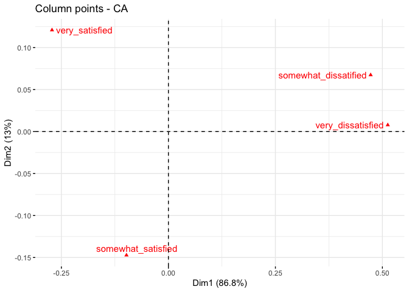

```r
#维度对列变量的代表性cos2（representation）
fviz_ca_col(res.ca, col.row = "cos2",
             gradient.cols = c("#00AFBB", "#E7B800", "#FC4E07"),
             repel = TRUE)
```

## 2.6 结论

从图中可以发现哪些组别关系紧密？

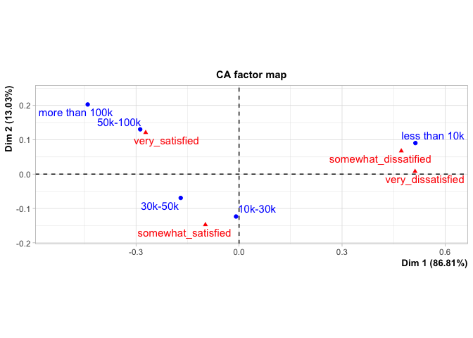

```
**Results of the Correspondence Analysis (CA)**
The row variable has  5  categories; the column variable has 4 categories
The chi square of independence between the two variables is equal to 118.0959 (p-value =  1.48029e-19 ).
*The results are available in the following objects:

   name              description
1  "$eig"            "eigenvalues"
2  "$col"            "results for the columns"
3  "$col$coord"      "coord. for the columns"
4  "$col$cos2"       "cos2 for the columns"
5  "$col$contrib"    "contributions of the columns"
6  "$row"            "results for the rows"
7  "$row$coord"      "coord. for the rows"
8  "$row$cos2"       "cos2 for the rows"
9  "$row$contrib"    "contributions of the rows"
10 "$call"           "summary called parameters"
11 "$call$marge.col" "weights of the columns"
12 "$call$marge.row" "weights of the rows"
```

```r
CA(ex2)
```

收入介于5万至10万与非常满意关系紧密。

收入小于1万与有些不满意关系紧密。